# final lstm model

```python
!pip install numpy==1.26.4
!pip install pandas
!pip install yfinance
!pip install scikit-learn
!pip install tensorflow
!pip install matplotlib
!pip install statsmodels
!pip install pandas-datareader
!pip install pandas-ta
```

```python
# Create directory
# $ mkdir my_log_dir

# To access http://localhost:6006
# $tensorboard --logdir=<mylogs>
```

```python
# supress warnings
import warnings
warnings.filterwarnings("ignore")

# base libraries
import os
import random
import numpy as np      # requires numpy version 1.26.4
import pandas as pd
import datetime
from pathlib import Path

# scikit-learn modules
from sklearn.preprocessing import MinMaxScaler
from sklearn.model_selection import train_test_split

# tensorflow modules
import tensorflow as tf
from tensorflow.keras.models import Sequential
from tensorflow.keras.layers import Dense, Dropout, Flatten, LSTM

from tensorflow.keras.layers import Input
from tensorflow.keras.models import Model, load_model
from tensorflow.keras.utils import plot_model
from tensorflow.keras.optimizers import Adam, RMSprop
from tensorflow.keras.preprocessing.sequence import TimeseriesGenerator
from tensorflow.keras.callbacks import EarlyStopping, ModelCheckpoint, TensorBoard

from tensorflow.keras.losses import BinaryCrossentropy
from tensorflow.keras.metrics import BinaryAccuracy, Accuracy, AUC, Precision, Recall

import logging
logging.getLogger('tensorflow').setLevel(logging.CRITICAL)

# plotting & outputs
import matplotlib.pyplot as plt
plt.style.use('seaborn-v0_8')

pd.set_option('display.max_columns', 30)
pd.set_option('display.max_rows', 1000)
```

```python
# set seed for reproducibility
def set_seeds(seed=2024):
    random.seed(seed)
    np.random.seed(seed)
    tf.random.set_seed(seed)

set_seeds()
```

```python
# Load the TensorBoard notebook extension
# %load_ext tensorboard
```

# Applying Neural Networks to Financial Time Series

```python
results_path = Path('results', 'lstm_time_series')
if not results_path.exists():
    results_path.mkdir(parents=True)
```

```python
import yfinance as yf

# Function to create sequences
def create_sequences(data, seq_length):
    X, y = [], []
    for i in range(len(data) - seq_length):
        X.append(data[i:(i + seq_length)])
        y.append(data[i + seq_length])
    return np.array(X), np.array(y)
```

```python
nifty_bank = yf.download('^NSEBANK', start='2019-01-01', end='2024-12-31')
df = nifty_bank[['Close']].copy()
```

```
[*********************100%***********************]  1 of 1 completed
```

```python
df['ret'] = np.log(df).diff().fillna(0)
df['dir'] = np.where(df.ret.shift(-1)>0,1,0)
df.tail(10)
```

| Price Ticker Date | Close ^NSEBANK | ret | dir |
| --- | --- | --- | --- |
| 2024-12-16 | 53581.351562 | -0.000046 | 0 |
| 2024-12-17 | 52834.800781 | -0.014031 | 0 |
| 2024-12-18 | 52139.550781 | -0.013246 | 0 |
| 2024-12-19 | 51575.699219 | -0.010873 | 0 |
| 2024-12-20 | 50759.199219 | -0.015958 | 1 |
| 2024-12-23 | 51317.601562 | 0.010941 | 0 |
| 2024-12-24 | 51233.000000 | -0.001650 | 0 |
| 2024-12-26 | 51170.699219 | -0.001217 | 1 |
| 2024-12-27 | 51311.300781 | 0.002744 | 0 |
| 2024-12-30 | 50952.750000 | -0.007012 | 0 |

# Feature Specification

Features are also known as an independent variable which are used to determine the value of the target variable. We will now calculate lagged returns and convert them into binary for our classification problem.

```python
# compute lagged returns
cols = []
for lag in [1,2,3,4,5,6,7]:
    col = f'ret_{lag}'
    df[col] = df.ret.shift(lag)
    cols.append(col)

# drop nan values
df.dropna(inplace=True)

# binary transformation
cols_bin = []
for col in cols:
    col_bin = f'{col}_bin'
    df[col_bin] = np.digitize(df[col], bins=[0])
    cols_bin.append(col_bin)

df
```

| Price Ticker Date | Close ^NSEBANK | ret | dir | ret_1 | ret_2 | ret_3 | ret_4 | ret_5 | ret_6 | ret_7 | ret_1_bin | ret_2_bin | ret_3_bin | ret_4_bin | ret_5_bin | ret_6_bin | ret_7_bin |
| --- | --- | --- | --- | --- | --- | --- | --- | --- | --- | --- | --- | --- | --- | --- | --- | --- | --- |
| 2019-01-11 | 27453.582031 | -0.002715 | 0 | -0.006945 | 0.007637 | 0.007478 | 0.004020 | 0.008684 | -0.007938 | 0.000000 | 0 | 1 | 1 | 1 | 1 | 0 | 1 |
| 2019-01-14 | 27247.933594 | -0.007519 | 1 | -0.002715 | -0.006945 | 0.007637 | 0.007478 | 0.004020 | 0.008684 | -0.007938 | 0 | 0 | 1 | 1 | 1 | 1 | 0 |
| 2019-01-15 | 27400.431641 | 0.005581 | 1 | -0.007519 | -0.002715 | -0.006945 | 0.007637 | 0.007478 | 0.004020 | 0.008684 | 0 | 0 | 0 | 1 | 1 | 1 | 1 |
| 2019-01-16 | 27483.378906 | 0.003023 | 1 | 0.005581 | -0.007519 | -0.002715 | -0.006945 | 0.007637 | 0.007478 | 0.004020 | 1 | 0 | 0 | 0 | 1 | 1 | 1 |
| 2019-01-17 | 27528.429688 | 0.001638 | 0 | 0.003023 | 0.005581 | -0.007519 | -0.002715 | -0.006945 | 0.007637 | 0.007478 | 1 | 1 | 0 | 0 | 0 | 1 | 1 |
| ... | ... | ... | ... | ... | ... | ... | ... | ... | ... | ... | ... | ... | ... | ... | ... | ... | ... |
| 2024-12-23 | 51317.601562 | 0.010941 | 0 | -0.015958 | -0.010873 | -0.013246 | -0.014031 | -0.000046 | 0.006879 | -0.003281 | 0 | 0 | 0 | 0 | 0 | 1 | 0 |
| 2024-12-24 | 51233.000000 | -0.001650 | 0 | 0.010941 | -0.015958 | -0.010873 | -0.013246 | -0.014031 | -0.000046 | 0.006879 | 1 | 0 | 0 | 0 | 0 | 0 | 1 |
| 2024-12-26 | 51170.699219 | -0.001217 | 1 | -0.001650 | 0.010941 | -0.015958 | -0.010873 | -0.013246 | -0.014031 | -0.000046 | 0 | 1 | 0 | 0 | 0 | 0 | 0 |
| 2024-12-27 | 51311.300781 | 0.002744 | 0 | -0.001217 | -0.001650 | 0.010941 | -0.015958 | -0.010873 | -0.013246 | -0.014031 | 0 | 0 | 1 | 0 | 0 | 0 | 0 |
| 2024-12-30 | 50952.750000 | -0.007012 | 0 | 0.002744 | -0.001217 | -0.001650 | 0.010941 | -0.015958 | -0.010873 | -0.013246 | 1 | 0 | 0 | 1 | 0 | 0 | 0 |

1465 rows × 17 columns

```python
# select only bin columns
X = df[cols_bin]
X
```

| Price Ticker Date | ret_1_bin | ret_2_bin | ret_3_bin | ret_4_bin | ret_5_bin | ret_6_bin | ret_7_bin |
| --- | --- | --- | --- | --- | --- | --- | --- |
| 2019-01-11 | 0 | 1 | 1 | 1 | 1 | 0 | 1 |
| 2019-01-14 | 0 | 0 | 1 | 1 | 1 | 1 | 0 |
| 2019-01-15 | 0 | 0 | 0 | 1 | 1 | 1 | 1 |
| 2019-01-16 | 1 | 0 | 0 | 0 | 1 | 1 | 1 |
| 2019-01-17 | 1 | 1 | 0 | 0 | 0 | 1 | 1 |
| ... | ... | ... | ... | ... | ... | ... | ... |
| 2024-12-23 | 0 | 0 | 0 | 0 | 0 | 1 | 0 |
| 2024-12-24 | 1 | 0 | 0 | 0 | 0 | 0 | 1 |
| 2024-12-26 | 0 | 1 | 0 | 0 | 0 | 0 | 0 |
| 2024-12-27 | 0 | 0 | 1 | 0 | 0 | 0 | 0 |
| 2024-12-30 | 1 | 0 | 0 | 1 | 0 | 0 | 0 |

1465 rows × 7 columns

```python
# specify target
y = df['dir']
y
```

```
Date
2019-01-11    0
2019-01-14    1
2019-01-15    1
2019-01-16    1
2019-01-17    0
             ..
2024-12-23    0
2024-12-24    0
2024-12-26    1
2024-12-27    0
2024-12-30    0
Name: dir, Length: 1465, dtype: int32
```

# Train & Split

```python
# Splitting the datasets into training and testing data.
Xtrain, Xtest, ytrain, ytest = train_test_split(X, y, test_size=0.2, shuffle=False)
# train, test = train_test_split(X, train_size=0.8, test_size=0.2, shuffle=False)

# Output the train and test data size
print(f"Train and Test Size {Xtrain.shape}, {ytrain.shape}, {Xtest.shape}, {ytest.shape}")
# print(f"Train and Test Size {train.shape}, {test.shape}")
```

```
Train and Test Size (1172, 7), (1172,), (293, 7), (293,)
```

# Feature Scaling

```python
# perform normalization
scaler = MinMaxScaler()
scaledtrain = scaler.fit_transform(Xtrain)
scaledtest = scaler.transform(Xtest)
```

```python
scaler
```

```
MinMaxScaler()
```

```python
scaledtrain
```

```
array([[0., 1., 1., ..., 1., 0., 1.],
       [0., 0., 1., ..., 1., 1., 0.],
       [0., 0., 0., ..., 1., 1., 1.],
       ...,
       [1., 1., 0., ..., 1., 0., 0.],
       [1., 1., 1., ..., 1., 1., 0.],
       [0., 1., 1., ..., 0., 1., 1.]])
```

```python
scaledtest
```

```
array([[0., 0., 1., ..., 1., 0., 1.],
       [1., 0., 0., ..., 1., 1., 0.],
       [0., 1., 0., ..., 1., 1., 1.],
       ...,
       [0., 1., 0., ..., 0., 0., 0.],
       [0., 0., 1., ..., 0., 0., 0.],
       [1., 0., 0., ..., 0., 0., 0.]])
```

# Sequence Data Generation

```python
# sequence length
seqlen = 21

# number of features
numfeat = X.shape[1]
```

```python
numfeat
```

```
7
```

```python
# generate train and test sequence data
g = TimeseriesGenerator(scaledtrain, ytrain, length=seqlen)
g_ = TimeseriesGenerator(scaledtest, ytest, length=seqlen)
```

```python
# verify length
len(g), len(g_)
```

```
(9, 3)
```

```python
# check feature set
g[0][0]
```

```
array([[[0., 1., 1., ..., 1., 0., 1.],
        [0., 0., 1., ..., 1., 1., 0.],
        [0., 0., 0., ..., 1., 1., 1.],
        ...,
        [1., 1., 0., ..., 1., 0., 0.],
        [1., 1., 1., ..., 1., 1., 0.],
        [0., 1., 1., ..., 0., 1., 1.]],

       [[0., 0., 1., ..., 1., 1., 0.],
        [0., 0., 0., ..., 1., 1., 1.],
        [1., 0., 0., ..., 1., 1., 1.],
        ...,
        [1., 1., 1., ..., 1., 1., 0.],
        [0., 1., 1., ..., 0., 1., 1.],
        [0., 0., 1., ..., 1., 0., 1.]],

       [[0., 0., 0., ..., 1., 1., 1.],
        [1., 0., 0., ..., 1., 1., 1.],
        [1., 1., 0., ..., 0., 1., 1.],
        ...,
        [0., 1., 1., ..., 0., 1., 1.],
        [0., 0., 1., ..., 1., 0., 1.],
        [0., 0., 0., ..., 1., 1., 0.]],

       ...,

       [[1., 1., 0., ..., 1., 0., 0.],
        [0., 1., 1., ..., 0., 1., 0.],
        [0., 0., 1., ..., 0., 0., 1.],
        ...,
        [0., 1., 1., ..., 1., 0., 0.],
        [1., 0., 1., ..., 0., 1., 0.],
        [1., 1., 0., ..., 1., 0., 1.]],

       [[0., 1., 1., ..., 0., 1., 0.],
        [0., 0., 1., ..., 0., 0., 1.],
        [0., 0., 0., ..., 1., 0., 0.],
        ...,
        [1., 0., 1., ..., 0., 1., 0.],
        [1., 1., 0., ..., 1., 0., 1.],
        [0., 1., 1., ..., 1., 1., 0.]],

       [[0., 0., 1., ..., 0., 0., 1.],
        [0., 0., 0., ..., 1., 0., 0.],
        [0., 0., 0., ..., 1., 1., 0.],
        ...,
        [1., 1., 0., ..., 1., 0., 1.],
        [0., 1., 1., ..., 1., 1., 0.],
        [0., 0., 1., ..., 0., 1., 1.]]])
```

```python
# check target
g[0][1]
```

```
array([0, 0, 0, 0, 1, 1, 1, 0, 1, 0, 0, 0, 1, 1, 1, 1, 0, 1, 1, 1, 1, 1,
       1, 1, 1, 0, 0, 1, 1, 1, 0, 1, 0, 0, 1, 0, 1, 0, 0, 1, 1, 1, 0, 0,
       0, 1, 0, 1, 0, 0, 1, 0, 0, 0, 0, 1, 0, 1, 0, 1, 1, 1, 0, 1, 0, 1,
       1, 0, 0, 1, 0, 1, 0, 0, 1, 0, 1, 0, 1, 0, 0, 1, 1, 1, 0, 0, 1, 1,
       1, 0, 1, 0, 1, 1, 1, 0, 0, 0, 1, 0, 0, 1, 1, 0, 0, 0, 0, 0, 1, 1,
       0, 0, 1, 0, 0, 0, 1, 0, 1, 1, 0, 1, 1, 0, 0, 0, 0, 0])
```

```python
# verify batch size
for i in range(len(g)):
    a, b = g[i]
    print(a.shape, b.shape)
```

```
(128, 21, 7) (128,)
(128, 21, 7) (128,)
(128, 21, 7) (128,)
(128, 21, 7) (128,)
(128, 21, 7) (128,)
(128, 21, 7) (128,)
(128, 21, 7) (128,)
(128, 21, 7) (128,)
(127, 21, 7) (127,)
```

# Build Neural Network

We'll use the Sequential class from keras model API to stack our LSTM Recurrent Neural Network. We then compile and train the model defined above. Iteratively, we can increase or decrease the epochs and batch size to get more accuracy.

```python
# Create a sequential model
def create_model(hu=256, lookback=60, features=1):

    tf.keras.backend.clear_session()

    # instantiate the model
    model = Sequential()

    model.add(LSTM(units=hu*2, input_shape=(lookback, features), activation = 'elu', return_sequences=True, name='LSTM1'))
    model.add(Dropout(0.4, name='Drouput1'))

    model.add(LSTM(units=hu, activation = 'elu', return_sequences=True, name='LSTM2'))
    model.add(Dropout(0.4, name='Drouput2'))

    model.add(LSTM(units=hu, activation = 'elu', return_sequences=False, name='LSTM3'))

    model.add(Dense(units=1, activation='sigmoid', name='Output'))

    # specify optimizer separately (preferred method))
    opt = Adam(learning_rate=0.001, epsilon=1e-08, decay=0.0)

    # model compilation - 'binary_crossentropy' - 'accuracy' - BinaryAccuracy(name='accuracy', threshold=0.5)
    model.compile(optimizer=opt,
                  loss=BinaryCrossentropy(),
                  metrics=['accuracy',
                           Precision(),
                           Recall(),
                            AUC()])

    return model
```

```python
# lstm network
model = create_model(hu=10, lookback=seqlen, features=numfeat)
```

```python
# summary
model.summary()
```

```
Model: "sequential"
```

```
┏━━━━━━━━━━━━━━━━━━━━━━━━━━━━━━━━━┳━━━━━━━━━━━━━━━━━━━━━━━━┳━━━━━━━━━━━━━━━┓
┃ Layer (type)                    ┃ Output Shape           ┃       Param # ┃
┡━━━━━━━━━━━━━━━━━━━━━━━━━━━━━━━━━╇━━━━━━━━━━━━━━━━━━━━━━━━╇━━━━━━━━━━━━━━━┩
│ LSTM1 (LSTM)                    │ (None, 21, 20)         │         2,240 │
├─────────────────────────────────┼────────────────────────┼───────────────┤
│ Drouput1 (Dropout)              │ (None, 21, 20)         │             0 │
├─────────────────────────────────┼────────────────────────┼───────────────┤
│ LSTM2 (LSTM)                    │ (None, 21, 10)         │         1,240 │
├─────────────────────────────────┼────────────────────────┼───────────────┤
│ Drouput2 (Dropout)              │ (None, 21, 10)         │             0 │
├─────────────────────────────────┼────────────────────────┼───────────────┤
│ LSTM3 (LSTM)                    │ (None, 10)             │           840 │
├─────────────────────────────────┼────────────────────────┼───────────────┤
│ Output (Dense)                  │ (None, 1)              │            11 │
└─────────────────────────────────┴────────────────────────┴───────────────┘
```

```
 Total params: 4,331 (16.92 KB)
```

```
 Trainable params: 4,331 (16.92 KB)
```

```
 Non-trainable params: 0 (0.00 B)
```

```python
# Specify callback functions
model_path = (results_path / 'model.keras').as_posix()
logdir = os.path.join("./tensorboard/logs", datetime.datetime.now().strftime("%Y%m%d-%H%M%S"))

my_callbacks = [
    EarlyStopping(patience=20, monitor='loss', mode='min', verbose=1, restore_best_weights=True),
    ModelCheckpoint(filepath=model_path, verbose=1, monitor='loss', save_best_only=True),
    TensorBoard(log_dir=logdir, histogram_freq=1)
]
```

```python
# Calculate steps per epoch
# steps_per_epoch = (len(ytrain) - seqlen) // 32  # Divide by batch size
from sklearn.utils.class_weight import compute_class_weight
import numpy as np

# Assuming ytrain contains the class labels
class_weights = compute_class_weight(
    class_weight='balanced',
    classes=np.unique(ytrain),
    y=ytrain
)
class_weight_dict = dict(enumerate(class_weights))

# Model fitting
model.fit(
    g,
    # steps_per_epoch=steps_per_epoch,
    epochs=100,
    verbose=1,
    callbacks=my_callbacks,
    shuffle=False
)
```

```
8/9 ━━━━━━━━━━━━━━━━━━━━ 0s 17ms/step - accuracy: 0.8104 - auc: 0.9044 - loss: 0.3825 - precision: 0.8024 - recall: 0.8415
Epoch 1: loss did not improve from 0.36570
9/9 ━━━━━━━━━━━━━━━━━━━━ 0s 28ms/step - accuracy: 0.8092 - auc: 0.9037 - loss: 0.3841 - precision: 0.8024 - recall: 0.8408
7/9 ━━━━━━━━━━━━━━━━━━━━ 0s 20ms/step - accuracy: 0.7970 - auc: 0.9000 - loss: 0.3901 - precision: 0.7951 - recall: 0.8175
Epoch 2: loss did not improve from 0.36570
9/9 ━━━━━━━━━━━━━━━━━━━━ 0s 32ms/step - accuracy: 0.7961 - auc: 0.8981 - loss: 0.3939 - precision: 0.7928 - recall: 0.8238
6/9 ━━━━━━━━━━━━━━━━━━━━ 0s 25ms/step - accuracy: 0.7924 - auc: 0.8978 - loss: 0.3890 - precision: 0.7825 - recall: 0.8260
Epoch 3: loss did not improve from 0.36570
9/9 ━━━━━━━━━━━━━━━━━━━━ 0s 31ms/step - accuracy: 0.7930 - auc: 0.8963 - loss: 0.3933 - precision: 0.7865 - recall: 0.8269
7/9 ━━━━━━━━━━━━━━━━━━━━ 0s 18ms/step - accuracy: 0.7771 - auc: 0.8822 - loss: 0.4139 - precision: 0.7621 - recall: 0.8268
Epoch 4: loss did not improve from 0.36570
9/9 ━━━━━━━━━━━━━━━━━━━━ 0s 29ms/step - accuracy: 0.7798 - auc: 0.8835 - loss: 0.4121 - precision: 0.7663 - recall: 0.8304
8/9 ━━━━━━━━━━━━━━━━━━━━ 0s 17ms/step - accuracy: 0.7793 - auc: 0.8916 - loss: 0.3972 - precision: 0.7813 - recall: 0.7956
Epoch 5: loss did not improve from 0.36570
9/9 ━━━━━━━━━━━━━━━━━━━━ 0s 27ms/step - accuracy: 0.7825 - auc: 0.8923 - loss: 0.3969 - precision: 0.7841 - recall: 0.8018
8/9 ━━━━━━━━━━━━━━━━━━━━ 0s 18ms/step - accuracy: 0.8145 - auc: 0.9113 - loss: 0.3758 - precision: 0.8151 - recall: 0.8306
Epoch 6: loss did not improve from 0.36570
9/9 ━━━━━━━━━━━━━━━━━━━━ 0s 27ms/step - accuracy: 0.8130 - auc: 0.9095 - loss: 0.3777 - precision: 0.8130 - recall: 0.8328
7/9 ━━━━━━━━━━━━━━━━━━━━ 0s 31ms/step - accuracy: 0.8145 - auc: 0.9062 - loss: 0.3794 - precision: 0.8293 - recall: 0.8090
Epoch 7: loss did not improve from 0.36570
9/9 ━━━━━━━━━━━━━━━━━━━━ 0s 39ms/step - accuracy: 0.8107 - auc: 0.9032 - loss: 0.3840 - precision: 0.8216 - recall: 0.8151
8/9 ━━━━━━━━━━━━━━━━━━━━ 0s 17ms/step - accuracy: 0.7877 - auc: 0.8800 - loss: 0.4261 - precision: 0.7817 - recall: 0.8197
Epoch 8: loss did not improve from 0.36570
9/9 ━━━━━━━━━━━━━━━━━━━━ 0s 29ms/step - accuracy: 0.7891 - auc: 0.8829 - loss: 0.4207 - precision: 0.7842 - recall: 0.8214
7/9 ━━━━━━━━━━━━━━━━━━━━ 0s 18ms/step - accuracy: 0.8206 - auc: 0.9125 - loss: 0.3719 - precision: 0.8180 - recall: 0.8396
Epoch 9: loss did not improve from 0.36570
9/9 ━━━━━━━━━━━━━━━━━━━━ 0s 28ms/step - accuracy: 0.8157 - auc: 0.9073 - loss: 0.3816 - precision: 0.8114 - recall: 0.8424
7/9 ━━━━━━━━━━━━━━━━━━━━ 0s 18ms/step - accuracy: 0.7720 - auc: 0.8726 - loss: 0.4426 - precision: 0.7626 - recall: 0.8115
Epoch 10: loss did not improve from 0.36570
9/9 ━━━━━━━━━━━━━━━━━━━━ 0s 30ms/step - accuracy: 0.7716 - auc: 0.8725 - loss: 0.4409 - precision: 0.7632 - recall: 0.8141
7/9 ━━━━━━━━━━━━━━━━━━━━ 0s 21ms/step - accuracy: 0.7843 - auc: 0.8895 - loss: 0.4044 - precision: 0.7792 - recall: 0.8113
Epoch 11: loss did not improve from 0.36570
9/9 ━━━━━━━━━━━━━━━━━━━━ 0s 33ms/step - accuracy: 0.7849 - auc: 0.8893 - loss: 0.4039 - precision: 0.7804 - recall: 0.8157
7/9 ━━━━━━━━━━━━━━━━━━━━ 0s 18ms/step - accuracy: 0.7783 - auc: 0.8978 - loss: 0.3871 - precision: 0.7814 - recall: 0.7912
Epoch 12: loss did not improve from 0.36570
9/9 ━━━━━━━━━━━━━━━━━━━━ 0s 27ms/step - accuracy: 0.7820 - auc: 0.8975 - loss: 0.3891 - precision: 0.7825 - recall: 0.8041
7/9 ━━━━━━━━━━━━━━━━━━━━ 0s 19ms/step - accuracy: 0.7997 - auc: 0.8932 - loss: 0.4120 - precision: 0.8009 - recall: 0.8149
Epoch 13: loss did not improve from 0.36570
9/9 ━━━━━━━━━━━━━━━━━━━━ 0s 27ms/step - accuracy: 0.7983 - auc: 0.8916 - loss: 0.4137 - precision: 0.7988 - recall: 0.8193
7/9 ━━━━━━━━━━━━━━━━━━━━ 0s 18ms/step - accuracy: 0.7841 - auc: 0.8937 - loss: 0.3956 - precision: 0.7820 - recall: 0.8076
```

[output cut: 246 more lines]

```
Epoch 96: loss did not improve from 0.34658
9/9 ━━━━━━━━━━━━━━━━━━━━ 1s 82ms/step - accuracy: 0.7637 - auc: 0.8659 - loss: 0.4471 - precision: 0.7828 - recall: 0.7561
9/9 ━━━━━━━━━━━━━━━━━━━━ 0s 52ms/step - accuracy: 0.7614 - auc: 0.8527 - loss: 0.4706 - precision: 0.7509 - recall: 0.8099
Epoch 97: loss did not improve from 0.34658
9/9 ━━━━━━━━━━━━━━━━━━━━ 1s 77ms/step - accuracy: 0.7636 - auc: 0.8555 - loss: 0.4663 - precision: 0.7535 - recall: 0.8117
9/9 ━━━━━━━━━━━━━━━━━━━━ 0s 45ms/step - accuracy: 0.8034 - auc: 0.9016 - loss: 0.3874 - precision: 0.8012 - recall: 0.8266
Epoch 98: loss did not improve from 0.34658
9/9 ━━━━━━━━━━━━━━━━━━━━ 1s 94ms/step - accuracy: 0.8035 - auc: 0.9015 - loss: 0.3876 - precision: 0.8007 - recall: 0.8288
8/9 ━━━━━━━━━━━━━━━━━━━━ 0s 50ms/step - accuracy: 0.8093 - auc: 0.9155 - loss: 0.3666 - precision: 0.8050 - recall: 0.8336
Epoch 99: loss did not improve from 0.34658
9/9 ━━━━━━━━━━━━━━━━━━━━ 1s 79ms/step - accuracy: 0.8091 - auc: 0.9147 - loss: 0.3679 - precision: 0.8038 - recall: 0.8374
9/9 ━━━━━━━━━━━━━━━━━━━━ 0s 46ms/step - accuracy: 0.8034 - auc: 0.9123 - loss: 0.3669 - precision: 0.8001 - recall: 0.8283
Epoch 100: loss did not improve from 0.34658
9/9 ━━━━━━━━━━━━━━━━━━━━ 1s 77ms/step - accuracy: 0.8036 - auc: 0.9122 - loss: 0.3671 - precision: 0.7999 - recall: 0.8303
Restoring model weights from the end of the best epoch: 88.
```

```
<keras.src.callbacks.history.History at 0x20744f01820>
```

# Evaluate model performance

Load Saved model

We'll now load the saved model can by calling the load_model() function and passing the filename. The function returns the model with the same architecture and weights and avoid tuning the model everytime.

```python
# load model - os.path.abspath(model_path)
model = load_model(model_path)

# summarize model
model.summary()

# evaluate the model
score = model.evaluate(g_, verbose=0)
print(f'{model.metrics_names[1]}, {score[1]*100:.4}%')
```

```
Model: "sequential"
```

```
┏━━━━━━━━━━━━━━━━━━━━━━━━━━━━━━━━━┳━━━━━━━━━━━━━━━━━━━━━━━━┳━━━━━━━━━━━━━━━┓
┃ Layer (type)                    ┃ Output Shape           ┃       Param # ┃
┡━━━━━━━━━━━━━━━━━━━━━━━━━━━━━━━━━╇━━━━━━━━━━━━━━━━━━━━━━━━╇━━━━━━━━━━━━━━━┩
│ LSTM1 (LSTM)                    │ (None, 21, 20)         │         2,240 │
├─────────────────────────────────┼────────────────────────┼───────────────┤
│ Drouput1 (Dropout)              │ (None, 21, 20)         │             0 │
├─────────────────────────────────┼────────────────────────┼───────────────┤
│ LSTM2 (LSTM)                    │ (None, 21, 10)         │         1,240 │
├─────────────────────────────────┼────────────────────────┼───────────────┤
│ Drouput2 (Dropout)              │ (None, 21, 10)         │             0 │
├─────────────────────────────────┼────────────────────────┼───────────────┤
│ LSTM3 (LSTM)                    │ (None, 10)             │           840 │
├─────────────────────────────────┼────────────────────────┼───────────────┤
│ Output (Dense)                  │ (None, 1)              │            11 │
└─────────────────────────────────┴────────────────────────┴───────────────┘
```

```
 Total params: 12,995 (50.77 KB)
```

```
 Trainable params: 4,331 (16.92 KB)
```

```
 Non-trainable params: 0 (0.00 B)
```

```
 Optimizer params: 8,664 (33.85 KB)
```

```
compile_metrics, 49.26%
```

```python
# predictions
# ypred = model.predict(g_, verbose=False)

ypred = np.where(model.predict(g_, verbose=False) > 0.5, 1, 0)
ypred[-10:]
```

```
array([[1],
       [0],
       [0],
       [0],
       [0],
       [0],
       [0],
       [1],
       [1],
       [1]])
```

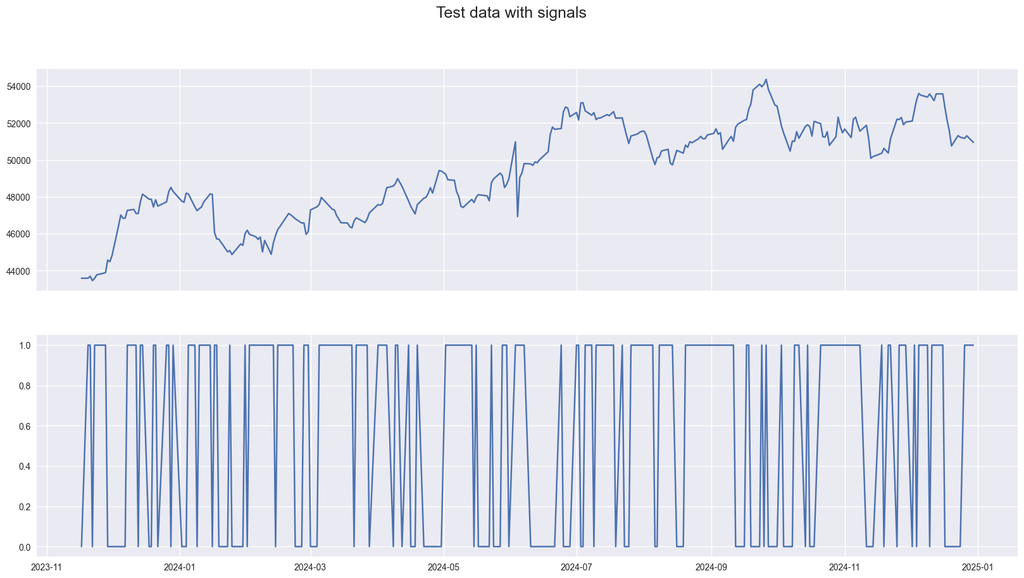

```python
# plot predictions
df1 = df.Close[-(len(Xtest)-seqlen):]
fig, axs = plt.subplots(2, sharex=True, figsize=(20,10))
fig.suptitle('Test data with signals', size=18)
axs[0].plot(df1.index, df1)
axs[1].plot(df1.index, ypred);
```

Hyperparameter Optimization

set before training the model and are not learned by the model during the training process while model parameters are learned by the model, from the data, during the training process

Some of the most common hyperparameters that can be optimised for better results are number of hidden layers, number of neurons, choice of activation function, number of epochs, learning rate, batch size and regularisation parameters.

Our goal is to get best performing model by choosing parameters that help in getting a model that is both precise and generalized.

KerasTuner

The Keras Tuner is a library that helps you pick the optimal set of hyperparameters for your TensorFlow program. The two most uses classes are

Hyperparameters class: used to specify a set of hyperparameters and their values that are to be used in the model building function.

Tuner class: subclasses corresponding to different tuning algorithms that are called directly by the user to start the search or to get the best models. Tuner is the base class for all tuners for Keras models. It manages building, training, evaluation and saving of the Keras models. New tuners can be created by subclassing the class.

```python
def build_model(hp):

    tf.keras.backend.clear_session()

    # instantiate the model
    model = Sequential()

    # Tune the number of units in the layers
    hp_units1 = hp.Int('units1', min_value=4, max_value=32, step=4)
    hp_units2 = hp.Int('units2', min_value=4, max_value=32, step=4)
    hp_units3 = hp.Int('units3', min_value=4, max_value=32, step=4)

    # Tune the dropout rate
    hp_dropout1 = hp.Float('Dropout_rate', min_value=0, max_value=0.5, step=0.1)
    hp_dropout2 = hp.Float('Dropout_rate', min_value=0, max_value=0.5, step=0.1)

    # Tune the learning rate for the optimizer
    hp_learning_rate = hp.Choice('learning_rate', values=[1e-2, 1e-3, 1e-4])

    # Tune activation functions
    hp_activation1 = hp.Choice(name = 'activation', values = ['relu', 'elu'], ordered = False)
    hp_activation2 = hp.Choice(name = 'activation', values = ['relu', 'elu'], ordered = False)
    hp_activation3 = hp.Choice(name = 'activation', values = ['relu', 'elu'], ordered = False)

    model.add(LSTM(hp_units1, input_shape=(seqlen, numfeat), activation=hp_activation1, return_sequences=True, name='LSTM1'))
    model.add(Dropout(hp_dropout1, name='Drouput1'))

    model.add(LSTM(hp_units2, activation = hp_activation2, return_sequences=True, name='LSTM2'))
    model.add(Dropout(hp_dropout2, name='Drouput2'))

    model.add(LSTM(hp_units3, activation = hp_activation3, return_sequences=False, name='LSTM3'))

    model.add(Dense(units=1, activation='sigmoid', name='Output'))

    # specify optimizer separately (preferred method))
    opt = Adam(learning_rate=hp_learning_rate, epsilon=1e-08, decay=0.0)

    # model compilation - 'binary_crossentropy' - 'accuracy' - BinaryAccuracy(name='accuracy', threshold=0.5)
    model.compile(optimizer=opt,
                  loss=BinaryCrossentropy(),
                  metrics=['accuracy',
                           Precision(),
                           Recall()])

    return model
```

```python
# initialize an early stopping callback to prevent the model from
# overfitting/spending too much time training with minimal gains
callback1 = [EarlyStopping(patience=5, monitor='loss', mode='min', verbose=1, restore_best_weights=True),
             TensorBoard(log_dir="./tensorboard/rslogs")]
```

```python
!pip install keras-tuner
```

```python
from keras_tuner.tuners import RandomSearch
# RandomSearch algorithm from keras tuner
rstuner = RandomSearch(
    build_model,
    objective="val_accuracy",
    max_trials=5,
    directory="./keras",
    project_name="rstrail",
    overwrite=True
)
```

```python
# launch tuning process
rstuner.search(g, epochs=100, validation_data=g_, callbacks=callback1, shuffle=False)
```

```
Trial 5 Complete [00h 00m 15s]
val_accuracy: 0.5367646813392639

Best val_accuracy So Far: 0.5441176295280457
Total elapsed time: 00h 01m 41s
```

```python
# display the best hyperparameter values for the model based on the defined objective function
best_rshp = rstuner.get_best_hyperparameters()[0]
print(best_rshp.values)
```

```
{'units1': 16, 'units2': 8, 'units3': 28, 'Dropout_rate': 0.1, 'learning_rate': 0.0001, 'activation': 'relu'}
```

```python
# display tuning results summary
rstuner.results_summary()
```

```
Results summary
Results in ./keras\rstrail
Showing 10 best trials
Objective(name="val_accuracy", direction="max")

Trial 1 summary
Hyperparameters:
units1: 16
units2: 8
units3: 28
Dropout_rate: 0.1
learning_rate: 0.0001
activation: relu
Score: 0.5441176295280457

Trial 0 summary
Hyperparameters:
units1: 32
units2: 28
units3: 4
Dropout_rate: 0.0
learning_rate: 0.01
activation: elu
Score: 0.5367646813392639

Trial 2 summary
Hyperparameters:
units1: 32
units2: 4
units3: 8
Dropout_rate: 0.1
learning_rate: 0.01
activation: elu
Score: 0.5367646813392639

Trial 3 summary
Hyperparameters:
units1: 24
units2: 8
units3: 8
Dropout_rate: 0.1
learning_rate: 0.001
activation: relu
Score: 0.5367646813392639

Trial 4 summary
Hyperparameters:
units1: 16
units2: 28
units3: 8
Dropout_rate: 0.0
learning_rate: 0.01
activation: relu
Score: 0.5367646813392639
```

```python
#%tensorboard --logdir ./tensorboard/rslogs
```